# PRS and Summary Statistics Analyses

Nicholas Mancuso

6/12/2024

## 1. Overview

### 1.1 Goals

1. Use PGSCatalog and download CAD PRS and perform downstream analyses
2. Perform multi-variate MR analysis of CAD using metabolites $\newcommand{\bG}{\mathbf{G}}$ $\newcommand{\bX}{\mathbf{X}}$ $\newcommand{\bz}{\mathbf{z}}$ $\newcommand{\by}{\hat{\mathbf{y}}}$ $\newcommand{\bbeta}{\boldsymbol{\beta}}$ $\newcommand{\balpha}{\boldsymbol{\alpha}}$ $\newcommand{\bbetahat}{\hat{\boldsymbol{\beta}}}$ $\newcommand{\balphahat}{\hat{\boldsymbol{\alpha}}}$

## 2. CAD Polygenic Risk Score Analyses

### 2.1 PRS Model

Let $\bG$ be the $N \times P$ genotype matrix for $N$ individuals at $P$ known risk SNPs. Similarly, let $\bbetahat$ be the $P \times 1$ vector of effect-size estimates from independent GWAS data. We can predict the $i$th individuals genetic component of risk by weighting genotype by their respective effect-sizes and taking their sum. Using mathematical notation this corresponds to,
$$\by_i = \sum_{j=1}^p \bG_{ij}
\bbetahat_j.$$
We can succinctly represent this for all our individuals using matrix notation as $\by = \bG \bbetahat$.

Given predicted risk scores $\by$, covariates $\bX$ and an exposure $\bz$, we can test for association between $\by$ and $\bz$. If robust, it provides evidence of genetic component of risk influencing our exposure. We can test using straightforward `lm` or `glm` depending on the structure of the exposure. For today’s analyses, we’ll be using `lm` since our exposures are continuous measures of expression.

### 2.2 PGS Catalog

The [PGS Catalog](https://www.pgscatalog.org/) is a website/databse of curated and harmonized PRS/PGS for >200 traits/diseases. Each PRS/PGS is annotated with relevant study information, prediction metrics, and how PRS/PGS was developed. For more information, please check out the website and corresponding paper by [Lambert et al. Nature Genetics 2021](https://www.nature.com/articles/s41588-021-00783-5).

### 2.3 Data Description

Geuvadis RNA sequencing data set contains 462 unrelated human lymphoblastoid cell line samples from the CEU, FIN, GBR, TSI and YRI populations from the [1000 Genomes](https://www.internationalgenome.org/). Sample collection was created by the [Geuvadis consortium](http://www.geuvadis.org). More details about RNA-seq Geuvadis project can be found [here](http://www.geuvadis.org/web/geuvadis/rnaseq-project) and from [Lappalainen et al. Nature 2013](http://dx.doi.org/10.1038/nature12531).

For our analysis we will be focusing on the quality-controlled and rank-normalized LCL expression located [here](https://www.ebi.ac.uk/arrayexpress/files/E-GEUV-1/GD462.GeneQuantRPKM.50FN.samplename.resk10.txt.gz). Of these, we will focus on 119 genes involved in cyto/chemokine production to focus on inflammation and inflammatory factors.

Our PRS of interest is derived from the [Koyama & Ito, et al Nat Genet 2020](https://www.nature.com/articles/s41588-020-0705-3) study on coronary artery disease (CAD). They performed large-scale CAD GWAS using 25,892 cases and 142,336 controls of Japanese ancestry. They then performed a trans-ethnic meta-analysis by combining summary statistics with two previous European-based CAD GWAS for a total of 121,234 CAD cases (BBJ: 25,892; C4D: 60,801; UKBB: 34,541) and 527,824 controls (BBJ: 142,336; C4D: 123,504; UKBB: 261,984).

The primary goal of this analysis will be to identify genes whose expression in LCLs is related to CAD risk through inflammation/inflammatory response.

### 2.4 Loading the PRS Data

Let’s first download PRS weights from the PGS Catalog and inspect the distribution of GWAS inferred effect-sizes. In general, GWAS effect sizes follow a mixture of normal distributions, but for PRS-selected variants, weights should deviate from zero (or else they would not be selected!) resulting in a mixture of two truncated distributions.

```r
# url to CAD PRS/PGS in the PGS Catalog
cad_url <- "http://ftp.ebi.ac.uk/pub/databases/spot/pgs/scores/PGS000337/ScoringFiles/PGS000337.txt.gz"
#cad_url <- "PGS000337.txt.gz"
# contains a header with comments indicated by '#'; let's skip those for now
df_prs <- readr::read_table(cad_url, comment = "#")

# print the first few rows and tibble info
df_prs
```

```
## # A tibble: 75,028 × 5
##    chr_name chr_position effect_allele effect_weight variant_description
##       <dbl>        <dbl> <chr>                 <dbl> <chr>
##  1        1       959231 A                    0.0113 1:959231:G:A
##  2        1      1119858 T                   -0.0166 1:1119858:C:T
##  3        1      1122024 C                    0.0135 1:1122024:T:C
##  4        1      1154858 T                   -0.0243 1:1154858:C:T
##  5        1      1171417 T                   -0.0127 1:1171417:C:T
##  6        1      1210352 G                   -0.0193 1:1210352:A:G
##  7        1      1211927 T                   -0.0211 1:1211927:C:T
##  8        1      1212795 A                   -0.0214 1:1212795:C:A
##  9        1      1215078 G                   -0.0209 1:1215078:A:G
## 10        1      1220136 G                   -0.0179 1:1220136:A:G
## # ℹ 75,018 more rows
```

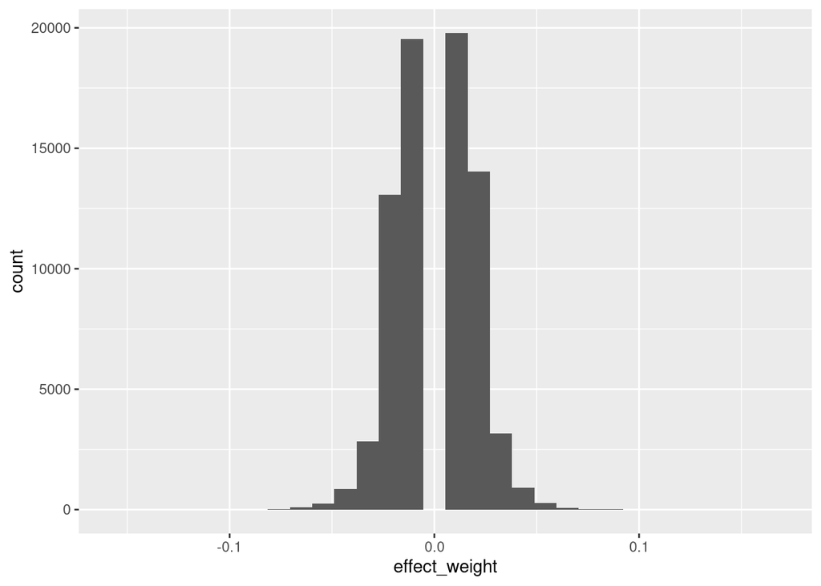

```r
# histogram of the weights in PRS/PGS; note weights should not overlap 0!
ggplot(df_prs, aes(effect_weight)) + geom_histogram()
```

### 2.5 Loading GEUVADIS

Let’s load our GEUVADIS individuals. I’ve pre-computed their CAD risk for simplicity. In practice this could be done using the `score` function in `PLINK` with appropriate parameters passed in. A simple sanity check should show a normal looking distribution of CAD risk.

```r
load("GEUVADIS.RData")

# inspect PRS + PCs
df_geuv
```

```
## # A tibble: 445 × 7
##    IID          PRS_CAD     PC1     PC2    PC3    PC4       PC5
##    <chr>          <dbl>   <dbl>   <dbl>  <dbl>  <dbl>     <dbl>
##  1 HG00096  0.0000471   0.00992 -0.0268 0.0120 0.0188 -0.000851
##  2 HG00097  0.0000529   0.0105  -0.0277 0.0120 0.0178  0.00204
##  3 HG00099  0.0000757   0.0102  -0.0270 0.0118 0.0159  0.00162
##  4 HG00100  0.0000634   0.00938 -0.0279 0.0123 0.0176 -0.00468
##  5 HG00101  0.0000750   0.00995 -0.0265 0.0130 0.0171  0.00137
##  6 HG00102  0.0000355   0.0104  -0.0276 0.0106 0.0155  0.00745
##  7 HG00103  0.000141    0.0103  -0.0271 0.0123 0.0183  0.00207
##  8 HG00105  0.000185    0.0102  -0.0270 0.0121 0.0170 -0.000696
##  9 HG00106  0.0000623   0.0106  -0.0270 0.0119 0.0165 -0.00429
## 10 HG00108 -0.000000658 0.00997 -0.0269 0.0130 0.0177  0.00184
## # ℹ 435 more rows
```

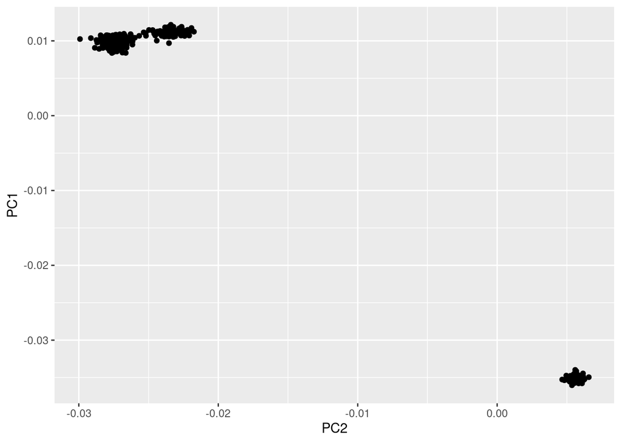

```r
# how does ancestry check out?
ggplot(df_geuv, aes(PC2, PC1)) +
  geom_point()
```

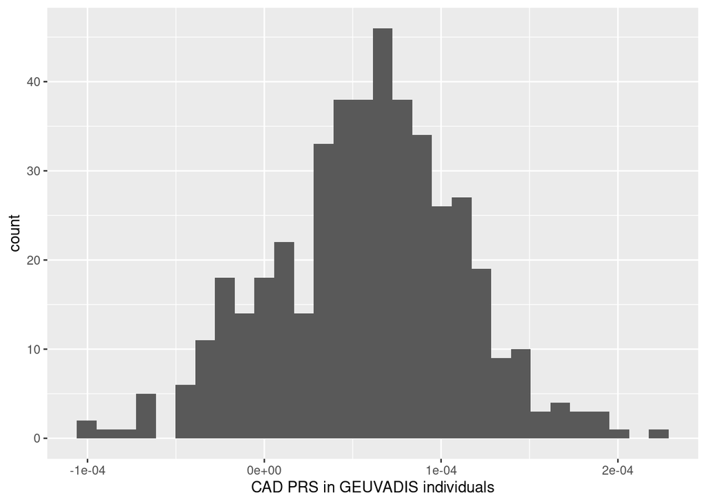

```r
# plot risk distribution
ggplot(df_geuv, aes(PRS_CAD)) +
  geom_histogram() +
  xlab("CAD PRS in GEUVADIS individuals")
```

```r
# how does PRS compare against PCs?
df_geuv %>%
  pivot_longer(-c(IID, PRS_CAD), names_to="PC") %>%
  group_by(PC) %>%
  do(broom::tidy(lm(value ~ PRS_CAD, data=.))) %>%
  filter(term == "PRS_CAD")
```

```
## # A tibble: 5 × 6
## # Groups:   PC [5]
##   PC    term    estimate std.error statistic  p.value
##   <chr> <chr>      <dbl>     <dbl>     <dbl>    <dbl>
## 1 PC1   PRS_CAD   -106.      15.3      -6.91 1.66e-11
## 2 PC2   PRS_CAD     86.3     10.7       8.06 7.21e-15
## 3 PC3   PRS_CAD    -23.8      4.10     -5.81 1.22e- 8
## 4 PC4   PRS_CAD    -47.9      5.85     -8.19 2.87e-15
## 5 PC5   PRS_CAD     40.6      7.04      5.76 1.55e- 8
```

### 2.6 Exposure scan with PRS

Now that we’ve downloaded our PRS and predicted CAD risk into GEUVADIS individuals, let’s inspect the expression data and then perform a gene-based scan. Here we’ll be performing multiple linear regression with CAD scores as a risk factor. We saw that PRS strongly correlated with ancestry, so let’s be sure to include genotyping PCs to adjust our PRS estimates.

```r
# inspect compiled tibble
df_geuv_f
```

```
## # A tibble: 52,955 × 9
##    IID       PRS_CAD     PC1     PC2    PC3    PC4       PC5 Gene          value
##    <chr>       <dbl>   <dbl>   <dbl>  <dbl>  <dbl>     <dbl> <chr>         <dbl>
##  1 HG00096 0.0000471 0.00992 -0.0268 0.0120 0.0188 -0.000851 ENSG000001…  1.20
##  2 HG00096 0.0000471 0.00992 -0.0268 0.0120 0.0188 -0.000851 ENSG000001…  4.75
##  3 HG00096 0.0000471 0.00992 -0.0268 0.0120 0.0188 -0.000851 ENSG000001…  1.00
##  4 HG00096 0.0000471 0.00992 -0.0268 0.0120 0.0188 -0.000851 ENSG000001…  0.437
##  5 HG00096 0.0000471 0.00992 -0.0268 0.0120 0.0188 -0.000851 ENSG000001…  0.145
##  6 HG00096 0.0000471 0.00992 -0.0268 0.0120 0.0188 -0.000851 ENSG000000… -0.0164
##  7 HG00096 0.0000471 0.00992 -0.0268 0.0120 0.0188 -0.000851 ENSG000001…  0.228
##  8 HG00096 0.0000471 0.00992 -0.0268 0.0120 0.0188 -0.000851 ENSG000001…  6.19
##  9 HG00096 0.0000471 0.00992 -0.0268 0.0120 0.0188 -0.000851 ENSG000001…  0.516
## 10 HG00096 0.0000471 0.00992 -0.0268 0.0120 0.0188 -0.000851 ENSG000000…  0.273
## # ℹ 52,945 more rows
```

```r
# for each gene: fit a linear regression of gene expression levels on PRS_CAD while adjusting for PC1-5
df_scan <- df_geuv_f %>%
  group_by(Gene) %>%
  do(broom::tidy(lm(value ~ PRS_CAD + PC1 + PC2 + PC3 + PC4 + PC5, data=.))) %>%
  filter(term == "PRS_CAD") %>%
  ungroup() %>%
  mutate(q.value = qvalue::qvalue(p.value)$qvalues) %>%
  arrange(p.value)

# check out genes with FDR < 0.2
df_scan %>% filter(q.value < 0.2)
```

```
## # A tibble: 2 × 7
##   Gene              term    estimate std.error statistic p.value q.value
##   <chr>             <chr>      <dbl>     <dbl>     <dbl>   <dbl>   <dbl>
## 1 ENSG00000188064.5 PRS_CAD     458.      142.      3.22 0.00138   0.164
## 2 ENSG00000175505.9 PRS_CAD   -4469.     1503.     -2.97 0.00311   0.185
```

Two genes, `ENSG00000188064.5` (`WNT7B`) and `ENSG00000175505.9` (`CLCF1`), show some evidence of association with CAD risk. Let’s inspect how expression levels actually track.

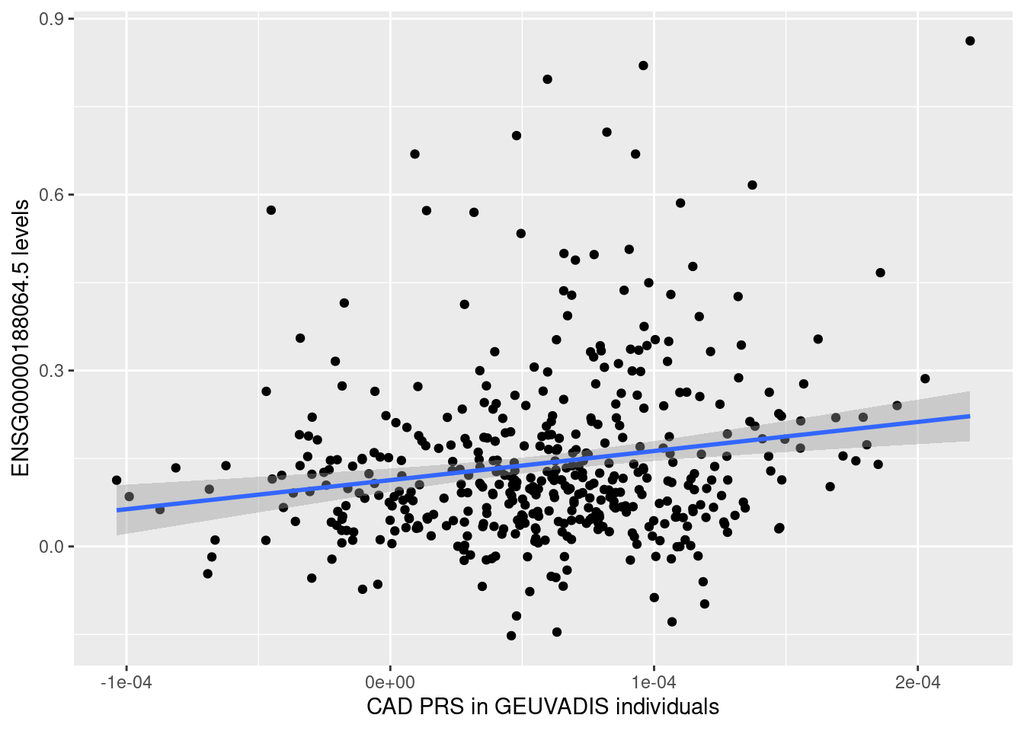

```r
# ENSG00000188064.5 is WNT7B and involved in Wnt signalling
ggplot(df_geuv_f %>% filter(Gene == "ENSG00000188064.5"), aes(PRS_CAD, value)) +
  geom_point() +
  geom_smooth(method="lm") +
  xlab("CAD PRS in GEUVADIS individuals") +
  ylab("ENSG00000188064.5 levels")
```

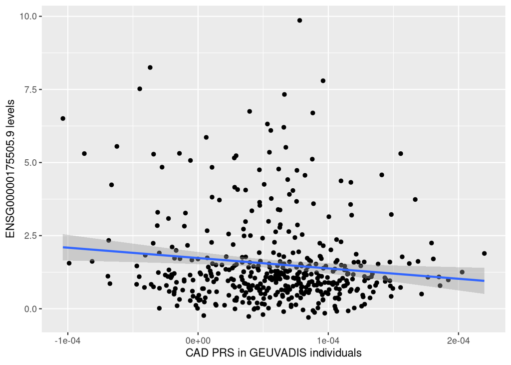

```r
# ENSG00000175505.9 is CLCF1 and involved in lipid metabolism
ggplot(df_geuv_f %>% filter(Gene == "ENSG00000175505.9"), aes(PRS_CAD, value)) +
  geom_point() +
  geom_smooth(method="lm") +
  xlab("CAD PRS in GEUVADIS individuals") +
  ylab("ENSG00000175505.9 levels")
```

## 3. CAD Multivariate MR Anaylsis

### 3.1 Mendelian Randomization

Let $\bbeta^{o}$ be the $P x 1$ latent effects for an outcome of interest $o$ and let $\bbeta^{x}$ be the $P \times 1$ latent effects for an exposure $x$. We can model a mediating relationship of $x$ on $o$ as $\bbeta^{o} = \bbeta^{x} \alpha$, where $\alpha$ is the mediating effect. If we observed $\bbeta^{o}, \bbeta^{x}$ directly we could estimate $\hat{\alpha}$ to test the hypothesis that $\alpha \neq 0$. Unfortunately, we are unable to observe $\bbeta^{o}, \bbeta^{x}$ directly, but we can replace them with estimates from GWAS $\bbetahat^{o}, \bbetahat^{x}$. This results in a model of
$$\bbetahat^{o} = \bbetahat^{x}\alpha +
\epsilon$$
where $\epsilon_j \sim N(0, s^2_j)$ and $s^2_j$ is the squared standard error of $\bbetahat^{o}_j$.

We can estimate $\hat{\alpha}$ using weighted least squares as
$$\hat{\alpha} = \frac{\sum_{j=1}^P (\bbetahat_j^x
/ s^2_j) \cdot \bbetahat_j^o}{\sum_{j=1}^P {\bbetahat_j^x}^2 /
s^2_j}.$$

$\newcommand{\bBhat}{\hat{\mathbf{B}}}$ $\newcommand{\bD}{\mathbf{D}}$ In practice we often have multiple exposures of interest $x_1, \dotsc, x_k$, many of which are correlated or have similar functions. We can leverage this and describe a multivariate mediation model as
$$\bbetahat^{o} = \bBhat \balpha +
\epsilon$$
where $\bBhat = [\bbetahat^{x_1}, \dotsc, \bbetahat^{x_k}]$ is the $P \times k$ matrix of effect-sizes across our $k$ exposures at the same $P$ SNPs.

We can infer the $k \times 1$ mediating effect vector $\balpha$ using weighted least squares as
$$\balphahat
= (\bBhat^T \bD \bBhat)^{-1} \bBhat^T \bD \bbetahat^o$$
where $\bD$ is $diag(s^{-2}_1, \dotsc, s^{-2}_k)$ is the diagonal matrix of the reciprocal squared standard errors.

### 3.2 MR Base

[MR Base](https://www.mrbase.org/) is a database and R package to perform robust, interpretable Mendelian Randomization analyses. The corresponding manuscript by [Hemani et al eLife 2018](https://elifesciences.org/articles/34408) describes it in detail.

### 3.4 MV MR Analysis of CAD

I’ve downloaded and prepared metabolite data for $\beta$-Hydroxybutyrate `met-d-bOHbutyrate`, DHA `met-d-DHA`, medium-sized HDL particles `met-d-M_HDL_PL_pct`, and small HDL particles `met-d-S_HDL_PL_pct` along with corresponding CAD effect-size estimates and standard errors.

```r
load("MVMR.RData")

df_beta
```

```
## # A tibble: 10 × 7
##    SNP          CAD  CAD.se `met-d-bOHbutyrate` `met-d-DHA` `met-d-M_HDL_PL_pct`
##    <chr>      <dbl>   <dbl>               <dbl>       <dbl>                <dbl>
##  1 rs1081…  0.0372  0.0209            0.0217        0.0410             -0.0192
##  2 rs1260… -0.0302  0.00717           0.0000920    -0.0467             -0.0356
##  3 rs1274… -0.104   0.00832          -0.0109       -0.0437              0.0402
##  4 rs1367…  0.0274  0.00747          -0.00180       0.0152              0.000828
##  5 rs1477…  0.0956  0.0196            0.0563        0.0113             -0.0685
##  6 rs2489…  0.0236  0.00696          -0.00504      -0.00107             0.0263
##  7 rs2892… -0.122   0.0252           -0.158        -0.0350             -0.0262
##  8 rs3820… -0.0356  0.00911          -0.00575      -0.0133              0.0280
##  9 rs5571… -0.0191  0.00892           0.00642      -0.00131             0.000599
## 10 rs704   -0.00454 0.00694           0.0129       -0.00681            -0.00616
## # ℹ 1 more variable: `met-d-S_HDL_PL_pct` <dbl>
```

Let’s perform MV-MR analysis of our metabolite exposures on CAD risk while weighting for the uncertainty in our CAD effect-size estimates. We find marginal evidence of `met-d-DHA` (Docosahexaenoic acid) affecting CAD risk.

```r
df_mvres <- broom::tidy(lm(CAD ~ `met-d-bOHbutyrate` + `met-d-DHA` + `met-d-M_HDL_PL_pct` + `met-d-S_HDL_PL_pct` + 0, weights = 1 / df_beta$CAD.se^2, data=df_beta))

df_mvres
```

```
## # A tibble: 4 × 5
##   term                 estimate std.error statistic p.value
##   <chr>                   <dbl>     <dbl>     <dbl>   <dbl>
## 1 `met-d-bOHbutyrate`     0.377     0.371     1.02   0.349
## 2 `met-d-DHA`             0.991     0.361     2.74   0.0337
## 3 `met-d-M_HDL_PL_pct`   -0.132     0.368    -0.359  0.732
## 4 `met-d-S_HDL_PL_pct`   -0.310     0.193    -1.60   0.161
```